This exercise uses the **Fuel Economy** data set from the **AppliedPredicitiveModeling** package.

Note: The following will set-up your environment for this exercise. If you get an error stating that the packages have not been found, you need to install those packages.

## Exercise 1

Hint: See `?cars2010`

- After the **Fuel Economy** data is loaded, combine three data sets into one data set. (Note: The name `dat` is very often used in these situations, `data` is a reserved R word.)

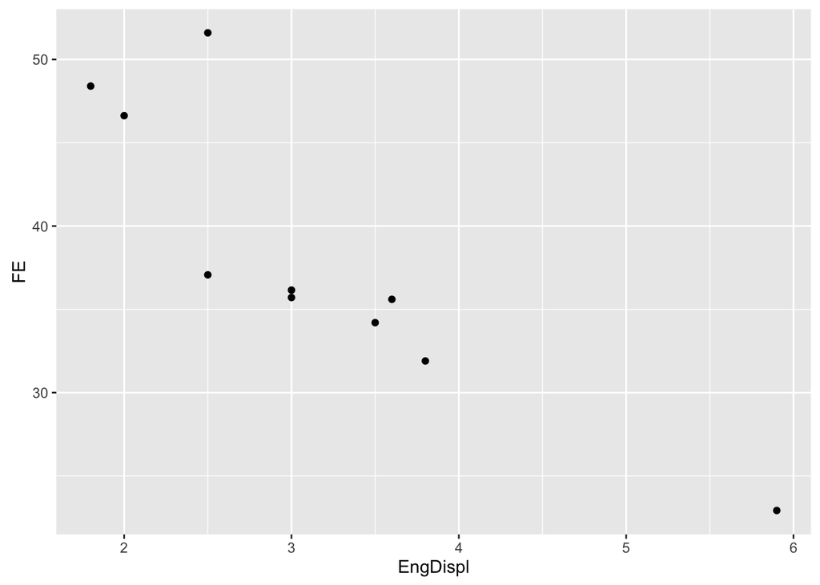

```r
dat3years <- rbind(cars2010,cars2011,cars2012)

naive_guess = mean(dat3years$FE)

set.seed(314)

samp <- dat3years %>% dplyr::sample_n(10) # you can also do just sample_n(10) since no conflicts with deep lyer package

samp %>% ggplot(aes(x=EngDispl, y=FE) ) + geom_point()
```

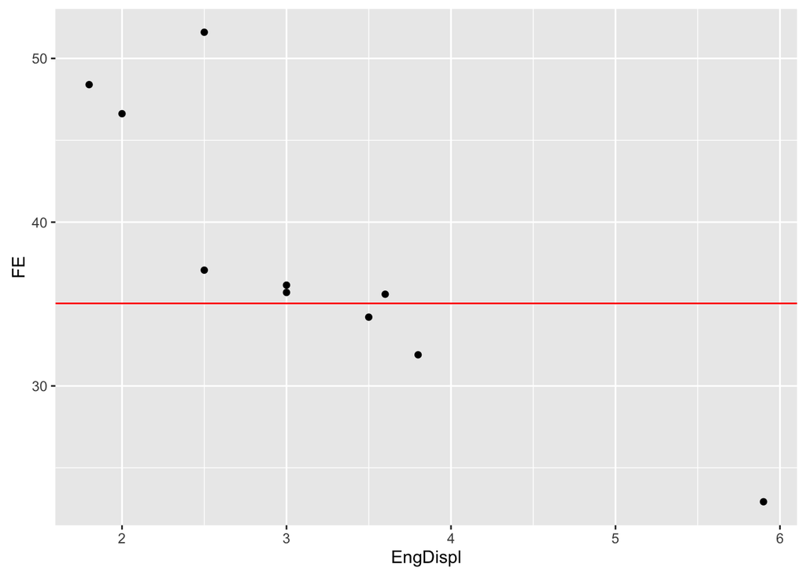

```r
#Naive guess (red line) is just a good place to start, always need a good place to start
samp %>% ggplot(aes(x=EngDispl, y=FE) ) + geom_point() + geom_hline(yintercept=naive_guess, color="red")
```

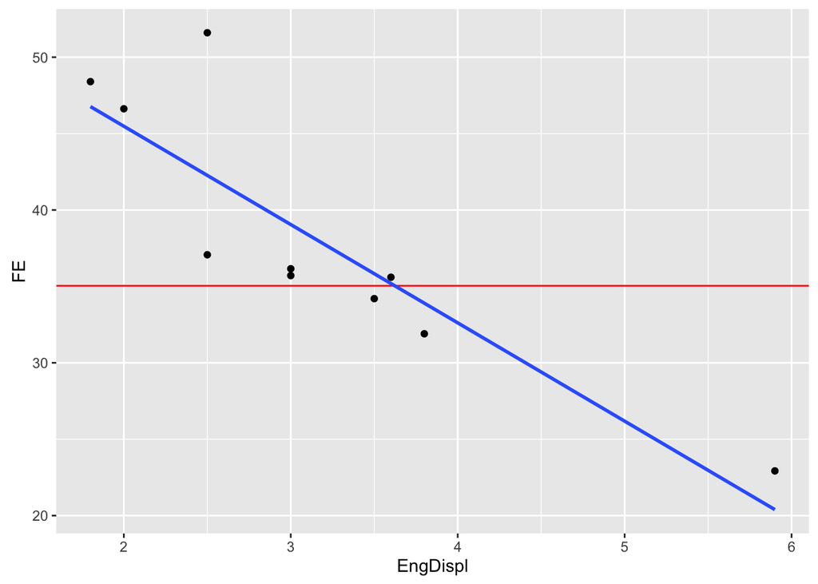

```r
#graph showing naive guess and linear model
samp %>% ggplot(aes(x=EngDispl, y=FE) ) + geom_point() + geom_hline(yintercept=naive_guess, color="red") + stat_smooth(method = "lm", se=FALSE)
```

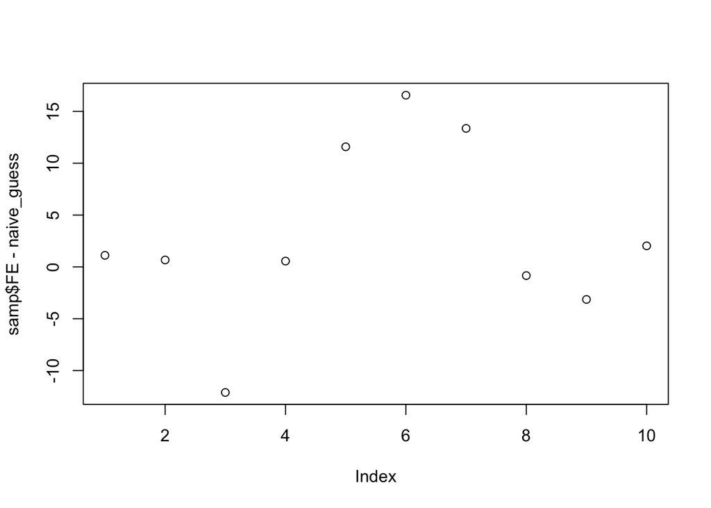

```r
plot(samp$FE - naive_guess)
```

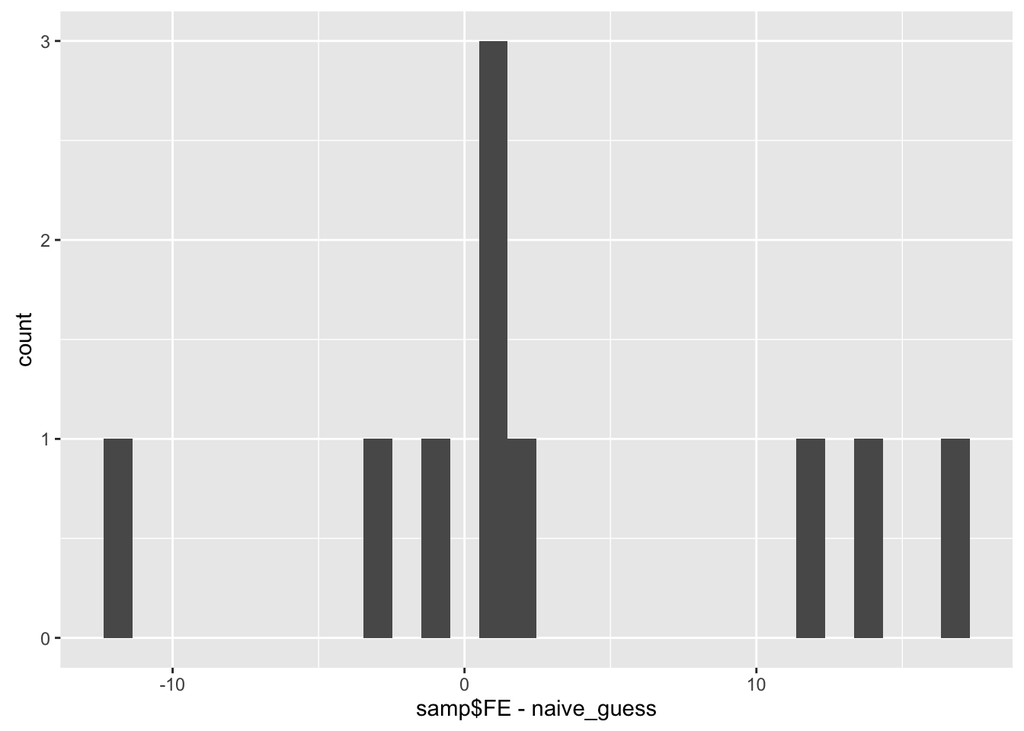

```r
qplot(samp$FE - naive_guess)
```

```r
#dat3years$FE

(dat3years$FE - naive_guess)^2 %>% mean %>% sqrt
```

```
## [1] 8.096176
```

```r
fit.dat3years <- lm(FE ~ EngDispl, data = dat3years)

fit.dat3years
```

```
##
## Call:
## lm(formula = FE ~ EngDispl, data = dat3years)
##
## Coefficients:
## (Intercept)     EngDispl
##      51.840       -4.792
```

```r
fit.dat3years <- lm(FE ~ EngDispl + NumCyl, data = dat3years)

fit.dat3years
```

```
##
## Call:
## lm(formula = FE ~ EngDispl + NumCyl, data = dat3years)
##
## Coefficients:
## (Intercept)     EngDispl       NumCyl
##     52.6096      -4.1561      -0.5015
```

```r
fit.dat3years <- lm(FE ~ EngDispl + NumCyl + NumGears, data = dat3years)

fit.dat3years
```

```
##
## Call:
## lm(formula = FE ~ EngDispl + NumCyl + NumGears, data = dat3years)
##
## Coefficients:
## (Intercept)     EngDispl       NumCyl     NumGears
##    52.75736     -4.16766     -0.48663     -0.03659
```

```r
fit.dat3years <- lm(FE ~ EngDispl + CarlineClassDesc + EngDispl, data = dat3years)

fit.dat3years
```

```
##
## Call:
## lm(formula = FE ~ EngDispl + CarlineClassDesc + EngDispl, data = dat3years)
##
## Coefficients:
##                                     (Intercept)
##                                         47.3513
##                                        EngDispl
##                                         -4.2855
##                        CarlineClassDesc2Seaters
##                                          3.3389
##                     CarlineClassDescCompactCars
##                                          5.7699
##                       CarlineClassDescLargeCars
##                                          3.9337
##                     CarlineClassDescMidsizeCars
##                                          5.4664
##                 CarlineClassDescMinicompactCars
##                                          4.8408
##            CarlineClassDescSmallPickupTrucks2WD
##                                         -1.4834
##            CarlineClassDescSmallPickupTrucks4WD
##                                         -1.8652
##              CarlineClassDescSmallStationWagons
##                                          2.7078
## CarlineClassDescSpecialPurposeVehicleminivan2WD
##                                          1.8885
##     CarlineClassDescSpecialPurposeVehicleSUV2WD
##                                          1.7443
##     CarlineClassDescSpecialPurposeVehicleSUV4WD
##                                         -0.7989
##         CarlineClassDescStandardPickupTrucks2WD
##                                          1.1908
##         CarlineClassDescStandardPickupTrucks4WD
##                                         -0.8495
##                  CarlineClassDescSubcompactCars
##                                          4.0061
##                  CarlineClassDescVansCargoTypes
##                                         -1.4134
##               CarlineClassDescVansPassengerType
##                                         -1.9240
```

```r
fit.dat3years %>% summary()
```

```
##
## Call:
## lm(formula = FE ~ EngDispl + CarlineClassDesc + EngDispl, data = dat3years)
##
## Residuals:
##      Min       1Q   Median       3Q      Max
## -15.5863  -2.5786  -0.3323   2.0675  24.5366
##
## Coefficients:
##                                                 Estimate Std. Error
## (Intercept)                                     47.35133    1.08855
## EngDispl                                        -4.28549    0.09444
## CarlineClassDesc2Seaters                         3.33895    1.13930
## CarlineClassDescCompactCars                      5.76985    1.09449
## CarlineClassDescLargeCars                        3.93368    1.14347
## CarlineClassDescMidsizeCars                      5.46636    1.10046
## CarlineClassDescMinicompactCars                  4.84079    1.17630
## CarlineClassDescSmallPickupTrucks2WD            -1.48338    1.26635
## CarlineClassDescSmallPickupTrucks4WD            -1.86522    1.37416
## CarlineClassDescSmallStationWagons               2.70785    1.15035
## CarlineClassDescSpecialPurposeVehicleminivan2WD  1.88848    1.41360
## CarlineClassDescSpecialPurposeVehicleSUV2WD      1.74434    1.10760
## CarlineClassDescSpecialPurposeVehicleSUV4WD     -0.79885    1.09391
## CarlineClassDescStandardPickupTrucks2WD          1.19076    1.27855
## CarlineClassDescStandardPickupTrucks4WD         -0.84945    1.26361
## CarlineClassDescSubcompactCars                   4.00608    1.10918
## CarlineClassDescVansCargoTypes                  -1.41338    1.40369
## CarlineClassDescVansPassengerType               -1.92396    1.46703
##                                                 t value Pr(>|t|)
## (Intercept)                                      43.500  < 2e-16 ***
## EngDispl                                        -45.377  < 2e-16 ***
## CarlineClassDesc2Seaters                          2.931 0.003436 **
## CarlineClassDescCompactCars                       5.272 1.56e-07 ***
## CarlineClassDescLargeCars                         3.440 0.000598 ***
## CarlineClassDescMidsizeCars                       4.967 7.61e-07 ***
## CarlineClassDescMinicompactCars                   4.115 4.09e-05 ***
## CarlineClassDescSmallPickupTrucks2WD             -1.171 0.241643
## CarlineClassDescSmallPickupTrucks4WD             -1.357 0.174883
## CarlineClassDescSmallStationWagons                2.354 0.018711 *
## CarlineClassDescSpecialPurposeVehicleminivan2WD   1.336 0.181784
## CarlineClassDescSpecialPurposeVehicleSUV2WD       1.575 0.115505
## CarlineClassDescSpecialPurposeVehicleSUV4WD      -0.730 0.465343
## CarlineClassDescStandardPickupTrucks2WD           0.931 0.351834
## CarlineClassDescStandardPickupTrucks4WD          -0.672 0.501537
## CarlineClassDescSubcompactCars                    3.612 0.000315 ***
## CarlineClassDescVansCargoTypes                   -1.007 0.314149
## CarlineClassDescVansPassengerType                -1.311 0.189913
## ---
## Signif. codes:  0 '***' 0.001 '**' 0.01 '*' 0.05 '.' 0.1 ' ' 1
##
## Residual standard error: 4.212 on 1429 degrees of freedom
## Multiple R-squared:  0.7328, Adjusted R-squared:  0.7296
## F-statistic: 230.5 on 17 and 1429 DF,  p-value: < 2.2e-16
```

```r
#dot means use all variables
fit.dat3years <- lm(FE ~ . + EngDispl, data = dat3years)

fit.dat3years
```

```
##
## Call:
## lm(formula = FE ~ . + EngDispl, data = dat3years)
##
## Coefficients:
##                                     (Intercept)
##                                        57.23884
##                                        EngDispl
##                                        -2.34608
##                                          NumCyl
##                                        -1.08024
##                                  TransmissionA4
##                                        -6.85302
##                                  TransmissionA5
##                                        -5.44388
##                                  TransmissionA6
##                                        -3.56074
##                                  TransmissionA7
##                                        -2.96101
##                                 TransmissionAM6
##                                        -5.54718
##                                 TransmissionAM7
##                                        -6.46621
##                                  TransmissionAV
##                                        -4.87101
##                                TransmissionAVS6
##                                        -7.71471
##                                  TransmissionM5
##                                        -6.08294
##                                  TransmissionM6
##                                        -5.82397
##                                  TransmissionS4
##                                        -9.49087
##                                  TransmissionS5
##                                        -7.02958
##                                  TransmissionS6
##                                        -4.41966
##                                  TransmissionS7
##                                        -4.30174
##                                  TransmissionS8
```

[output cut: 44 more lines]

```
##                                         0.39161
##         CarlineClassDescStandardPickupTrucks2WD
##                                        -0.53602
##         CarlineClassDescStandardPickupTrucks4WD
##                                        -0.99735
##                  CarlineClassDescSubcompactCars
##                                         3.85189
##                  CarlineClassDescVansCargoTypes
##                                        -3.30398
##               CarlineClassDescVansPassengerType
##                                        -4.51100
##                                  VarValveTiming
##                                         0.21536
##                                    VarValveLift
##                                         1.07734
```

```r
#sample 10 CarlineClassDesc
dat3years %>% select(CarlineClassDesc) %>% sample_n(10)
```

```
##                 CarlineClassDesc
## 1622                   LargeCars
## 1255              SubcompactCars
## 1438                 CompactCars
## 1396                 CompactCars
## 1817     StandardPickupTrucks2WD
## 1653                   LargeCars
## 2129 SpecialPurposeVehicleSUV4WD
## 1837     StandardPickupTrucks4WD
## 1143                    2Seaters
## 1573                 MidsizeCars
```

```r
#print table count for each CarlineClassDesc type
dat3years %>% select(CarlineClassDesc) %>% table
```

```
## .
##                           Other                        2Seaters
##                              16                              98
##                     CompactCars                       LargeCars
##                             199                              98
##                     MidsizeCars                 MinicompactCars
##                             175                              65
##            SmallPickupTrucks2WD            SmallPickupTrucks4WD
##                              36                              23
##              SmallStationWagons SpecialPurposeVehicleminivan2WD
##                              84                              20
##     SpecialPurposeVehicleSUV2WD     SpecialPurposeVehicleSUV4WD
##                             154                             218
##         StandardPickupTrucks2WD         StandardPickupTrucks4WD
##                              36                              39
##                  SubcompactCars                  VansCargoTypes
##                             146                              22
##               VansPassengerType
##                              18
```

- What is a good “naive guess” of FE? Show your work

```r
dat3years <- rbind(cars2010,cars2011,cars2012)

naive_guess = mean(dat3years$FE)

naive_guess
```

```
## [1] 35.03823
```

- plot FE (Fuel Econonomy) vs. EngDisp. Plot the naive guess.

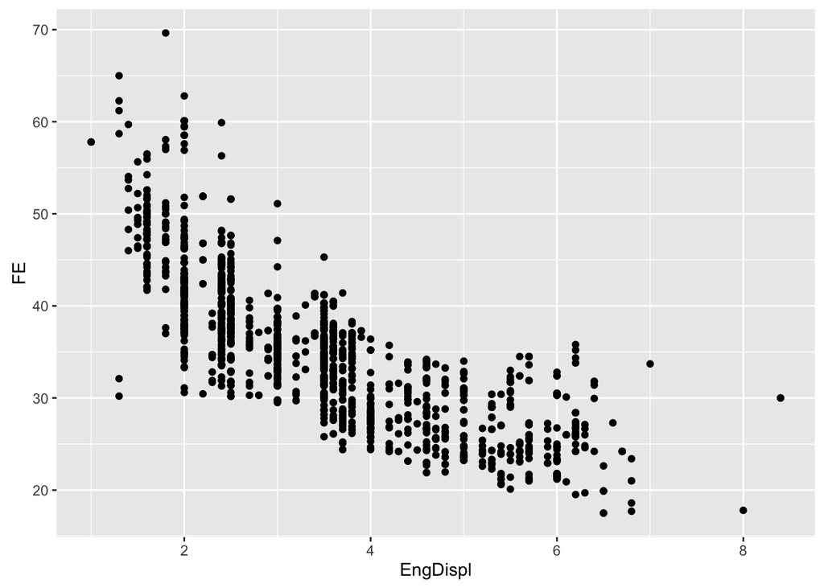

```r
# ... ggplot2

dat3years %>% ggplot(aes(x=EngDispl, y=FE) ) + geom_point()
```

- Sample 10 observations from `dat`
- Plot this data. Add a line for the naive_guess.

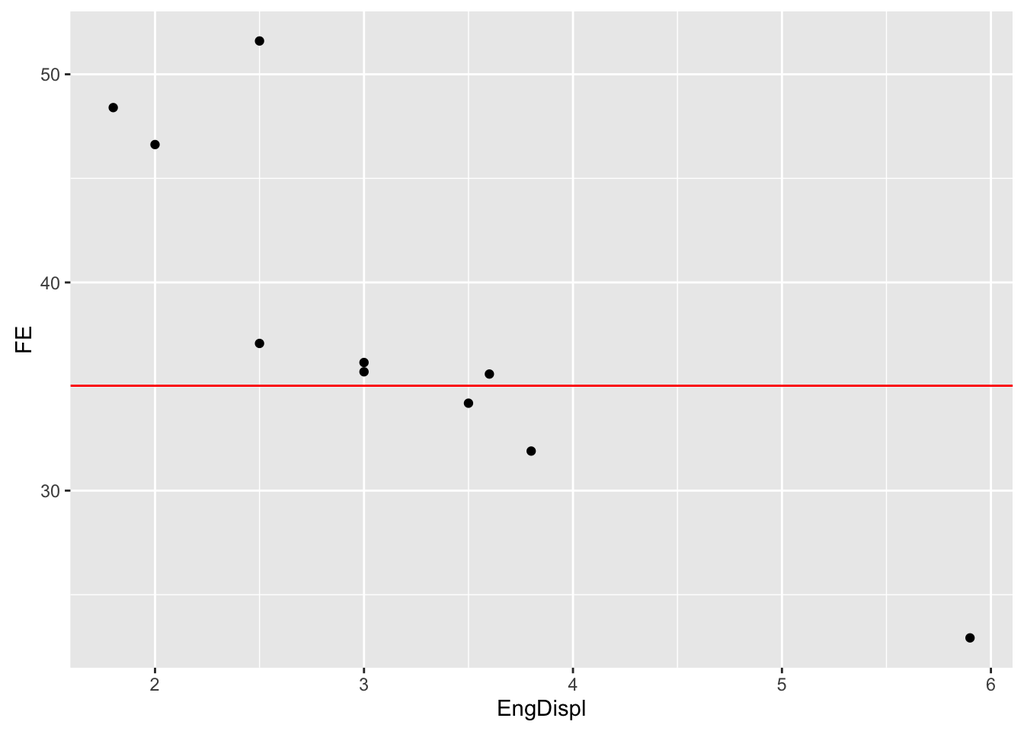

```r
set.seed(314)

# Sample

samp <- dat3years %>% dplyr::sample_n(10)

#Naive guess (red line) is just a good place to start, always need a good place to start
samp %>% ggplot(aes(x=EngDispl, y=FE) ) + geom_point() + geom_hline(yintercept=naive_guess, color="red")
```

## Exercise 2:

Write a loss functions for calculating:

- Root Mean Square Error
- Mean Absolute Error
- Median Absolute Error

All functions should accept two arguments:

```r
rmse <- function(y,yhat) {

  ( y - yhat )^2  %>% mean %>% sqrt
}

mae <- function(y, yhat) {

  abs( y - yhat ) %>% mean()
}

medae <- function(y, yhat) {

  abs( y - yhat ) %>% median()
}
```

## Exercise 3: Linear Model and Model Performance

- Use `lm` to create a linear model fitting the relationship between FE and EngDispl for the cars2010 data set

```r
fit.2010 <- lm( FE ~ EngDispl, data=cars2010 )
```

- Use your functions to evaluate the training error
- Use your model to: – predict the FE for 2011. What is the RMSE errors associated with the predictions. – predict the FE for 2012. What is the RMSE errors associated with the predictions.

```r
#Predict FE for 2010, 2011, 2012 using lm from 2010
y.2010 <- predict( fit.2010, data=cars2010 )
y.2011 <- predict( fit.2010, data=cars2011 )
y.2012 <- predict( fit.2010, data=cars2012 )

#Calculate RMSE error
rmse.2010 <- rmse( cars2010$FE,y.2010)
rmse.2011 <- rmse( cars2011$FE,y.2011)
rmse.2012 <- rmse( cars2012$FE,y.2012)
# DO NOT EDIT
rmse.2010
```

```
## [1] 4.620076
```

```r
rmse.2011
```

```
## [1] 11.33028
```

```r
rmse.2012
```

```
## [1] 12.94582
```

## Exercise 4:

- Model the fuel economy (`FE`) as a function of `EngDispl`, `NumCyl` and `VarValve` using the `cars2011` data set.
- Provide betas

```r
fit.2011 <- lm( FE ~ EngDispl + NumCyl + VarValveTiming, data=cars2011 )

summary(fit.2011)
```

```
##
## Call:
## lm(formula = FE ~ EngDispl + NumCyl + VarValveTiming, data = cars2011)
##
## Residuals:
##     Min      1Q  Median      3Q     Max
## -10.687  -2.768  -0.960   2.279  19.124
##
## Coefficients:
##                Estimate Std. Error t value Pr(>|t|)
## (Intercept)     52.6644     1.4701  35.823  < 2e-16 ***
## EngDispl        -3.9056     0.5246  -7.445 1.71e-12 ***
## NumCyl          -1.1102     0.4268  -2.601  0.00987 **
## VarValveTiming   3.5937     0.8862   4.055 6.76e-05 ***
## ---
## Signif. codes:  0 '***' 0.001 '**' 0.01 '*' 0.05 '.' 0.1 ' ' 1
##
## Residual standard error: 4.828 on 241 degrees of freedom
## Multiple R-squared:  0.7283, Adjusted R-squared:  0.725
## F-statistic: 215.4 on 3 and 241 DF,  p-value: < 2.2e-16
```

```r
coef(fit.2011)
```

```
##    (Intercept)       EngDispl         NumCyl VarValveTiming
##      52.664445      -3.905643      -1.110172       3.593704
```